# Boston Housing Guide

## Part 1: Descriptive analysis

```python
from sklearn.datasets import load_boston
bdata = load_boston()
```

```python
%matplotlib inline
import pandas as pd
import numpy as np
import matplotlib.pyplot as plt

#hint: Consult the scikit-learn documentation to
#      learn about what these classes do do
from sklearn.model_selection import cross_val_score
from sklearn.model_selection import train_test_split
from sklearn.naive_bayes import MultinomialNB
from sklearn.feature_extraction.text import CountVectorizer
import statsmodels.formula.api as smf
from sklearn.metrics import mean_squared_error
from sklearn.preprocessing import StandardScaler
from sklearn.decomposition import PCA
from sklearn.model_selection import KFold
from sklearn.metrics import accuracy_score
from sklearn.metrics import roc_auc_score, make_scorer
```

```python
to_dataframe = pd.DataFrame(bdata.data)
```

```python
to_dataframe.columns = ['CRIM', 'ZN', 'INDUS', 'CHAS', 'NOX', 'RM', 'AGE', 'DIS', 'RAD', 'TAX','PTRATIO','B','LSTAT']
```

```python
bdata2 = to_dataframe
```

```python
bdata2_target = pd.DataFrame(bdata.target)
```

```python
bdata2_target.columns = ['MEDV']
```

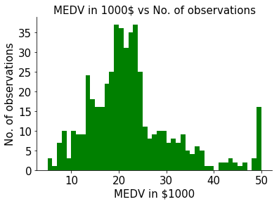

```python
# prepare your jupyter notebook to work with matplotlib and import the library to something convenient
%matplotlib inline
import matplotlib.pyplot as plt

# edit the code below to make the graph look good
ax = plt.subplot(111)

plt.hist(bdata.target, bins = np.arange(5, 50 + 1, 1), color = 'green' )

plt.title('MEDV in 1000$ vs No. of observations', fontsize = 15)
plt.xlabel('MEDV in $1000',fontsize = 15)
plt.ylabel('No. of observations',fontsize = 15)
plt.xticks(fontsize = 15)
plt.yticks(fontsize = 15)


ax.spines["right"].set_visible(False)
ax.spines["top"].set_visible(False)
```

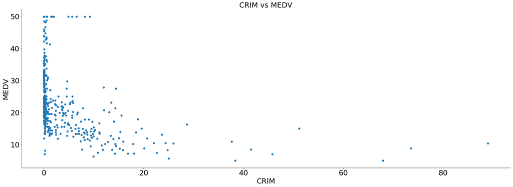

```python
fig, ax2 = plt.subplots()

fig.set_size_inches(30,10)

plt.scatter(bdata2['CRIM'], bdata2_target)

plt.title('CRIM vs MEDV', fontsize = 25)
plt.xlabel('CRIM', fontsize = 25)
plt.ylabel('MEDV', fontsize = 25)
plt.xticks(fontsize = 25)
plt.yticks(fontsize = 25)

ax2.spines["right"].set_visible(False)
ax2.spines["top"].set_visible(False)
```

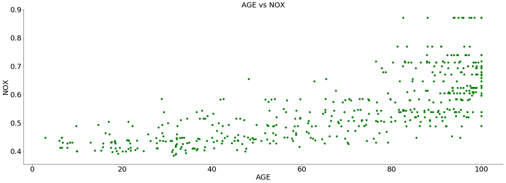

```python
fig, ax3 = plt.subplots()

fig.set_size_inches(30,10)

plt.scatter(bdata2['AGE'], bdata2['NOX'], color='green')

plt.title('AGE vs NOX', fontsize = 25)
plt.xlabel('AGE', fontsize = 25)
plt.ylabel('NOX', fontsize = 25)
plt.xticks(fontsize = 25)
plt.yticks(fontsize = 25)


ax3.spines["right"].set_visible(False)
ax3.spines["top"].set_visible(False)
```

## Part 2: Experimental Setup

### Writing a function to compute the Root Mean Squared Error for a list of numbers

```python
"""
Function
--------
compute_rmse

Given two arrays, one of actual values and one of predicted values,
compute the Roote Mean Squared Error

Parameters
----------
predictions : array
    Array of numerical values corresponding to predictions for each of the N observations

yvalues : array
    Array of numerical values corresponding to the actual values for each of the N observations

Returns
-------
rmse : int
    Root Mean Squared Error of the prediction

Example
-------
>>> print compute_rmse((2,2,3),(0,2,6)
2.16
"""
def compute_rmse(predictions, yvalues):
    return np.sqrt(((predictions - yvalues) ** 2).mean())
```

```python
# leave the following line untouched, it will help ensure that your "random" split is the same "random" split used by the rest of the class
np.random.seed(seed=13579)

#Calculate indices
r = bdata2.shape[0]
test_size = int(r*0.66)
df_test_indices = np.random.choice(range(0, r), size = test_size, replace=False)

#Create a dataframe from indices formed
bdata_train = bdata2.iloc[df_test_indices, ]
bdata_test = bdata2.iloc[~bdata2.index.isin(df_test_indices)]
bdata_target_train = bdata2_target.iloc[df_test_indices, ]
bdata_target_test = bdata2_target.iloc[~bdata2_target.index.isin(df_test_indices)]
```

```python
def model(df , computed):
    MD = list()
    mean_of_MDEV = computed
    for i in range(len(df)):
        MD.append(mean_of_MDEV)
    return MD

#Compute mean of Target Train
computed_mean = bdata_target_train.mean()

#Fit the model and compute RMSE on Train and Test
RMSE_Train = model(bdata_train, computed_mean)
rmse1 = compute_rmse(RMSE_Train, np.array(bdata_target_train))
print("RMSE on Training Data: ", rmse1)

RMSE_Test = model(bdata_test, computed_mean)
rmse2 = compute_rmse(RMSE_Test, np.array(bdata_target_test))
print("RMSE on Testing Data: ", rmse2)
```

```
RMSE on Training Data:  8.584967883775533
RMSE on Testing Data:  10.281671624776735
```

The RMSE Value for testing data when calculated with respect to the mean of the training data, is higher. This is expected since we are using the mean of a different dataset. If we had used the mean of the testing data for computing the rmse, we would have got a lower value for RMSE on Testing Data since the mean would more closely represent the test data than the train mean does in our case.

## Nearest Neighbors

### Nearest Neighbors: Distance function

A generic function to compute the L-Norm distance (called the *p*-norm distance on Wikipedia) is shown below.

```python
"""
Function
--------
distance

Given two instances and a value for L, return the L-Norm distance between them

Parameters
----------
x1, x2 : array
    Array of numerical values corresponding to predictions for each of the N observations

L: int
    Value of L to use in computing distances

Returns
-------
dist : int
    The L-norm distance between instances

Example
-------
>>> print distance((3,4),(6,8),2)
5

"""
def distance(x1, x2, L):
    length = len(x1)
    n = 1
    if(L == 0): #L0 norm is 1
        return 1
    total_dist = 0
    total_dist2 = 0

    #Iterate over any of the arrays and compute Summation((x1[i]-x2[i])^L)^(1/L)
    for i in range(len(x1)):
        total_dist = ((abs(x1[i]-x2[i]))**L)
        total_dist2 = total_dist2 + total_dist
        dist = pow(total_dist2,(1/L))
    return int(dist) #Return an integer value

dist = distance((3,4),(6,8),2)
print(dist)
```

```
5
```

### Basic Nearest Neighbor algorithm from scratch

```python
"""
Function
--------
nneighbor

Given X_Train, X_Test, Y_Train, Y_Test and values for L and K, return the RMSE

Parameters
----------
df1, df2, df3, df4 : dataframe
    df1 = X_Test
    df2 = X_Train
    df3 = Y_Train
    df4 = Y_Test

L: int
    Value of L to use in computing distances

K: int
    Value of K for the no. of nearest neighbors

Returns
-------
RMSE : Float
    Error between predicted and actual values

"""
from collections import OrderedDict
import time

#Create test and train dataframe with CRIM and RM with features
test1 = bdata_test['CRIM'].tolist()
test2 = bdata_test['RM'].tolist()
test = pd.DataFrame({'CRIM':test1, 'RM':test2})

train1 = bdata_train['CRIM'].tolist()
train2 = bdata_train['RM'].tolist()
train = pd.DataFrame({'CRIM':train1, 'RM':train2})

def nneighbor(df1, df2, df3, df4, L, k):
    start_time = time.time()
    MEDV = list()
    new_dict = dict()

    #Convert dataframe values to numpy array
    test = df1.values
    train = df2.values
    to_array_df3 = df3.values

    #Loop over test and train to calculate distance of each instance, and then store index as key and distance as value in a dictionary
    for idx, val in enumerate(test):
        for idx2, val2 in enumerate(train):
            dist = distance(test[idx], train[idx2], L)
            new_dict[idx2] = dist

        #Sort the dictionary by values
        sorted_dict = OrderedDict(sorted(new_dict.items(),key=lambda x: x[1] ))
        ks = list(sorted_dict) #Convert sorted dictionary to list to get keys(indices)
        index_list=list()
        index_list.append(ks[0:k]) #Take K nearest neighbors and append to a list
        index_final = index_list[0][:]
        total = 0

        #Find the corresponding MEDV Values with the indexes found above
        for j in index_final:
            total = total + to_array_df3[j]
        #Find mean of MEDV of nearest neigbors if K > 1
        mean_of_k_nearest = total/k
        MEDV.append(mean_of_k_nearest) #Append to an empty list the predicted values
        new_dict = dict()
        index_list=list()

    #print ("Time taken: " + str(round(time.time() - start_time,2)) + " seconds")
    rmse = compute_rmse(MEDV, np.array(df4))
    return rmse

rmse_knn = nneighbor(test, train, bdata_target_train,bdata_target_test, 2, 1)
print("Computed RMSE is: ", rmse_knn)
```

```
Computed RMSE is:  8.529459320530114
```

### Results and Normalization

```python
"""

Function
--------
normalize

Given raw_data as an array return the normalized data

Parameters
----------
raw_data : array

Returns
-------
Normalized Array : Array

"""
def normalize(raw_data):
    #Normalized data is data-mean divided by standard deviation
    normalized_data = (raw_data-np.mean(raw_data))/float(np.std(raw_data))
    return normalized_data

##Create dataframes which contains all normalized values

#Create test dataframe with CRIM and RM
test_data1 = bdata_test['CRIM'].tolist() #Convert to arrays
test_data2 = np.array(bdata_test['RM'])
test1 = normalize(test_data1) #normalize
test2 = normalize(test_data2)

test_CRIM_RM = pd.DataFrame({'CRIM':test1, 'RM':test2}) #Combine to form a dataframe

#Create train dataframe with CRIM and RM
train_data1 = bdata_train['CRIM'].tolist() #Convert to arrays
train_data2 = np.array(bdata_train['RM'])
train1 = normalize(train_data1) #normalize
train2 = normalize(train_data2)

train_CRIM_RM = pd.DataFrame({'CRIM':train1, 'RM':train2}) #Combine to form a dataframe

#Normalize Target dataframes

#Normalize bdata_target_training
normalized_target = np.array(bdata_target_train)
bdata2_target_train = normalize(normalized_target)
bdata_target_training = pd.DataFrame(bdata2_target_train)

#Normalize bdata_target_testing
normalized_target_test = np.array(bdata_target_test)
bdata2_target_test = normalize(normalized_target_test)
bdata_target_testing = pd.DataFrame(bdata2_target_test)

rmse_normalized_knn = nneighbor(test_CRIM_RM, train_CRIM_RM, bdata_target_training,bdata_target_testing, 2,1)
print("Normalized RMSE is: ", rmse_normalized_knn)
```

```
Normalized RMSE is:  0.8142267854185723
```

We obtain a much lower RMSE than above. This is because the KNN algorithm works best when scale of the predictor variables are similar. The distance obtained is better when all variables are scaled properly.

### Optimization

```python
#For 2 features

##Create dataframes which contains all normalized values of features
test_data1 = bdata_test['RM'].tolist()
test_data2 = np.array(bdata_test['NOX'])
test1 = normalize(test_data1)
test2 = normalize(test_data2)

test = pd.DataFrame({'RM':test1, 'NOX':test2})

train_data1 = bdata_train['RM'].tolist()
train_data2 = np.array(bdata_train['NOX'])
train1 = normalize(train_data1)
train2 = normalize(train_data2)

train = pd.DataFrame({'RM':train1, 'NOX':train2})

rmse_normalized_knn = nneighbor(test, train, bdata_target_training,bdata_target_testing, 2,1)
print("After normalizing, RMSE with RM and NOX as features is: ", rmse_normalized_knn)

#For 4 features

#Create dataframe with required features and then normalize
test_data1 = bdata_test['RM'].tolist()
test_data2 = bdata_test['NOX'].tolist()
test_data3 = bdata_test['RAD'].tolist()
test_data4 = bdata_test['TAX'].tolist()
test_data5 = bdata_test['DIS'].tolist()
test1 = normalize(test_data1)
test2 = normalize(test_data2)
test3 = normalize(test_data3)
test4 = normalize(test_data4)
test5 = normalize(test_data5)

test = pd.DataFrame({'RM':test1, 'NOX':test2, 'RAD':test3, 'TAX':test4, 'DIS':test5})

train_data1 = bdata_train['RM'].tolist()
train_data2 = bdata_train['NOX'].tolist()
train_data3 = bdata_train['RAD'].tolist()
train_data4 = bdata_train['TAX'].tolist()
train_data5 = bdata_train['DIS'].tolist()
train1 = normalize(train_data1)
train2 = normalize(train_data2)
train3 = normalize(train_data3)
train4 = normalize(train_data4)
train5 = normalize(train_data5)

train = pd.DataFrame({'RM':train1, 'NOX':train2, 'RAD':train3, 'TAX':train4, 'DIS': train5})

rmse_normalized_knn = nneighbor(test, train, bdata_target_training,bdata_target_testing, 2,1)
print("After normalizing, RMSE with RM, NOX, RAD, TAX, DIS as features is:",rmse_normalized_knn)

#Different Value of L with L=1
test_data1 = bdata_test['RM'].tolist()
test_data2 = np.array(bdata_test['NOX'])
test1 = normalize(test_data1)
test2 = normalize(test_data2)

test = pd.DataFrame({'RM':test1, 'NOX':test2})

train_data1 = bdata_train['RM'].tolist()
train_data2 = np.array(bdata_train['NOX'])
train1 = normalize(train_data1)
train2 = normalize(train_data2)

train = pd.DataFrame({'RM':train1, 'NOX':train2})

rmse_normalized_knn = nneighbor(test, train, bdata_target_training,bdata_target_testing, 1,1)
print("After normalizing, RMSE with L = 1 is: ", rmse_normalized_knn)

rmse_normalized_knn = nneighbor(test, train, bdata_target_training,bdata_target_testing, 5,1)
print("After normalizing, RMSE with L = 2 is: ", rmse_normalized_knn)
```

```
After normalizing, RMSE with RM and NOX as features is:  0.9337215657434479
After normalizing, RMSE with RM, NOX, RAD, TAX, DIS as features is: 0.8590866614907307
After normalizing, RMSE with L = 1 is:  0.8653913677823731
After normalizing, RMSE with L = 2 is:  0.9083351475311476
```

If we change the value of L to 1 and compute RMSE with RM and NOX as features, we get a lower value than computed before. If we increase the value of L, the computing time is higher.

### Cross-Validation

```python
"""

Function
--------
kfoldcv

Given bdata and bdata_target, no. of folds, L and K, this function returns the average RMSE for all the folds

Parameters
----------
data1, data2 : dataframe
    data1 = Data without the target variable
    data2 = Data containing only target variable

L: int
    Value of L to use in computing distances

K: int
    Value of K for the no. of nearest neighbors

Returns
-------
Average RMSE : Float
    Average RMSE of all 10 folds

"""

# Creating functions to get indices of k-fold data
def separate(l, n):
    for i in range(0, len(l), n):
        yield l[i:i+n]

# K-fold cross validation function
def kfoldcv(data, data2, fold, L, K):

    # Creating buckets each with indices
    buckets = list(separate(list(range(len(data))),int(len(data)/fold)))

    # Making sure that the we only have K buckets.
    if len(buckets) > fold:
        buckets[fold-1] = buckets[fold-1] + buckets[fold]
        buckets.remove(buckets[fold])

    rmse = []

    # Splitting data into train and test using 'k-1' folds for train and 1 fold for test
    for i in range(fold):
        test_ind = buckets[i]
        train_ind = range(len(data))
        train_ind = [elem for elem in train_ind if elem not in test_ind]

        train = data.iloc[train_ind,]
        test = data.iloc[test_ind,]
        train_target = data2.iloc[train_ind,]
        test_target = data2.iloc[test_ind, ]

        # Calculate the RMSE of each of the k-folds using the function specified at the input
        rmse.append(nneighbor(test, train, train_target, test_target, 2, K))
        average_rmse = np.mean(rmse)

    # Return the mean of the all the RMSE of the K-fold CV
    return average_rmse

start_time = time.time()
np.random.seed(seed=13579)

#Shuffle the bdata and bdata_target dataset with seed value as 13579 to get the shuffled indices
bdata3 = bdata2.reindex(np.random.permutation(bdata2.index))
bdata3_target = bdata2_target.iloc[bdata3.index, ]

#Make dataframes with the shuffled indices and taking CRIM and RM as features. Then normalize the dataframe
bdata2_CRIM_RM = bdata3[['CRIM','RM']].copy()
trainin_data1 = bdata2_CRIM_RM['CRIM'].tolist()
trainin_data2 = bdata2_CRIM_RM['RM'].tolist()
trainin1 = normalize(trainin_data1)
trainin2 = normalize(trainin_data2)

bdata_CRIM_RM = pd.DataFrame({'CRIM':trainin1, 'RM':trainin2})

#Make a similar dataframe for the target values and compute normalized dataframe
testin_data1 = bdata3_target.values
testin1 = normalize(testin_data1)

bdata_target= pd.DataFrame(testin1)

avg_rmse = kfoldcv(bdata_CRIM_RM, bdata_target, 10, 2, 1) #K=1 and L=2

# Print average RMSE for whole k- fold CV
print("Average RMSE is ", avg_rmse)

# Total time taken for the CV
#print("Total Time taken for CV ", (time.time()-start_time))
```

```
Average RMSE is  0.7294003791825328
```

### K-Nearest Neighbors Algorithm

```python
"""

Function
--------
knn

Given bdata and bdata_target, L and K, this function returns the average RMSE for all the folds

Parameters
----------
data1, data2 : dataframe
    data1 = Data without the target variable and containing the required features
    data2 = Data containing only target variable

L: int
    Value of L to use in computing distances

K: int
    Value of K for the no. of nearest neighbors

Returns
-------
Average RMSE : Float
    Average RMSE of all 10 folds

"""
def knn(data1, data2, L, K):

    avg_rmse_k = kfoldcv(data1, data2, 10, L, K)

    return avg_rmse_k

average_rmse_for_k3 = knn(bdata_CRIM_RM,bdata_target, 2,3)

# Print average RMSE for whole k- fold CV
print("Average RMSE is ", average_rmse_for_k3)

# Total time taken for the CV
#print("Total Time taken for CV ", (time.time()-start_time))
```

```
Average RMSE is  0.6133713997877843
```

### Using cross validation to find K

```python
rmse_list=list()
K_list=list()

#Create normalized training dataframe with CRIM, ZN, RM, AGE, DIS and TAX
bdata2_features = bdata3[['CRIM','ZN','RM','AGE','DIS','TAX']].copy()
trainin_data1 = bdata2_features['CRIM'].tolist()
trainin_data2 = bdata2_features['ZN'].tolist()
trainin_data3 = bdata2_features['RM'].tolist()
trainin_data4 = bdata2_features['AGE'].tolist()
trainin_data5 = bdata2_features['DIS'].tolist()
trainin_data6 = bdata2_features['TAX'].tolist()

trainin1 = normalize(trainin_data1)
trainin2 = normalize(trainin_data2)
trainin3 = normalize(trainin_data3)
trainin4 = normalize(trainin_data4)
trainin5 = normalize(trainin_data5)
trainin6 = normalize(trainin_data6)

bdata_features = pd.DataFrame({'CRIM':trainin1, 'ZN':trainin2, 'RM':trainin3, 'AGE':trainin4, 'DIS':trainin5, 'TAX':trainin6})

#Create normalized testing dataframe
testin_data1 = bdata3_target.values
testin1 = normalize(testin_data1)

bdata_target= pd.DataFrame(testin1)

#Loop for k value from 1 to 25
for i in range(1,25):
    rmse_list.append(knn(bdata_features, bdata_target, 2,i)) #Append Avg. RMSE to list
    K_list.append(i) #Append K to list
```

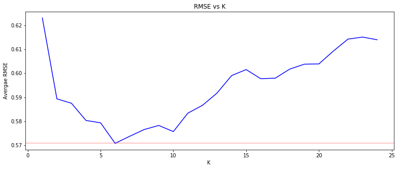

```python
#Plot between List of Avg. RMSE and K
plt.figure(figsize=(13,5))
plot = plt.plot( K_list,rmse_list, color = 'b')
plt.axhline(y = min(rmse_list), c = 'r', alpha = 0.3)
plt.title('RMSE vs K')
plt.xlabel('K ')
plt.ylabel('Avergae RMSE')
plt.show()
```

## Principal Component Analysis

```
MEDV    6.385031
dtype: float64
MEDV    6.896155
dtype: float64
```

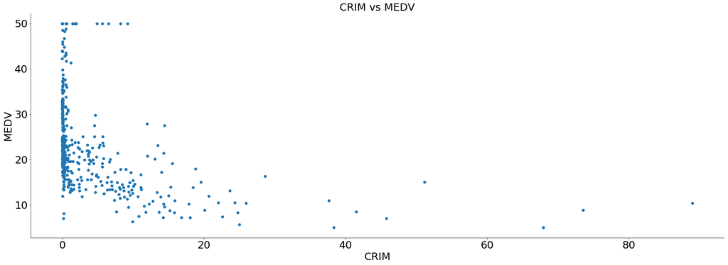

```python
# Enter your code here
fig, ax2 = plt.subplots()

fig.set_size_inches(30,10)

plt.scatter(bdata2['CRIM'], bdata2_target)

plt.title('CRIM vs MEDV', fontsize = 25)
plt.xlabel('CRIM', fontsize = 25)
plt.ylabel('MEDV', fontsize = 25)
plt.xticks(fontsize = 25)
plt.yticks(fontsize = 25)

ax2.spines["right"].set_visible(False)
ax2.spines["top"].set_visible(False)

#Run an OLS Regression
from sklearn.linear_model import LinearRegression

def linear_regression(data, target, predict):
    #initialize predictors:
    predictors=predict

    #Fit the model
    linreg = LinearRegression(normalize=True)
    linreg.fit(data[predictors],target)
    y_pred = linreg.predict(data[predictors])

    return np.sqrt(np.mean(np.square(target - y_pred)))

X_train, X_test, Y_train, Y_test = train_test_split(bdata2, bdata2_target, test_size=0.34, random_state=48)

predictors = ['RM']

RMSE_Train = linear_regression(X_train,Y_train, predictors)
RMSE_Test = linear_regression(X_test,Y_test, predictors)

print(RMSE_Train)
print(RMSE_Test)
```

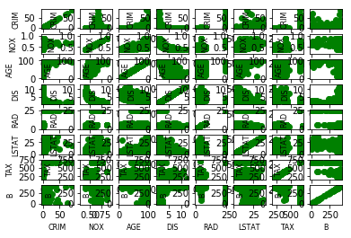

```python
plt.figure(figsize=(15,15))
# for i in range(8):
#     for j in range(8):
#         fig, ax = plt.subplots(8, 8, i * 8 + j + 1)
#         # insert your code here
#         ax[1].plot(bdata2['AGE'], bdata2['NOX'], color='green')

array = ['CRIM','NOX','AGE','DIS','RAD','LSTAT','TAX','B']
fig, ax = plt.subplots(8, 8)
for i in range(8):
    for j in range(8):
        fig.subplots_adjust(hspace=0.3)
        ax[j][i].scatter(bdata2[array[i]], bdata2[array[j]], color='green')
        ax[j][i].set_xlabel('{0}'.format(array[i]), fontsize = 8)
        ax[j][i].set_ylabel('{0}'.format(array[j]), fontsize = 8)

# ax[0].plot(bdata2['AGE'], bdata2['NOX'], color='green')
```

### PCA to the rescue

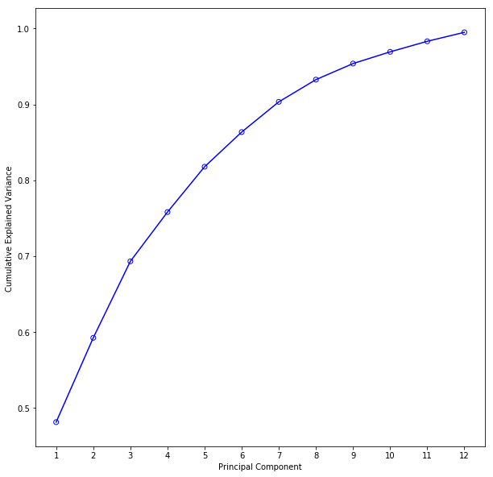

```python
# Enter your code here
from sklearn.decomposition import PCA

def normalize(raw_data):
    mu = np.mean(raw_data, axis = 0)
    std = np.std(raw_data, axis = 0)
    normalized_data = (raw_data - mu) / std
    return normalized_data

pca = PCA(n_components=12)
normalized = normalize(X_train)
pca.fit(normalized)
d=pd.DataFrame(pca.components_, columns = bdata2.columns, index = ['PC1', 'PC2', 'PC3', 'PC4','PC5','PC6','PC7','PC8','PC9','PC10','PC11','PC12'])
pd.Series(pca.explained_variance_ratio_, name = 'Explained Ratio', index = ['PC1', 'PC2', 'PC3', 'PC4','PC5','PC6','PC7','PC8','PC9','PC10','PC11','PC12'])

fig, ax = plt.subplots(figsize=(10, 10))
x = [1,2,3,4,5,6,7,8,9,10,11,12]
y = np.cumsum(pca.explained_variance_ratio_)
ax.scatter(x, y, color = 'blue' , facecolors='none')
ax.plot(x,y, color = 'blue')
ax.set_xlabel('Principal Component')
ax.set_ylabel('Cumulative Explained Variance ')
ax.xaxis.set_ticks(np.arange(1, 13, 1))
```

### Visualizing the components

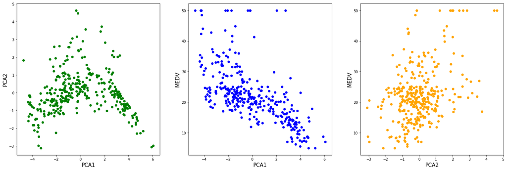

```python
# Enter your code here
fig2, ax2 = plt.subplots(1, 3, figsize=(25,8), squeeze=False)


normalized = normalize(X_train)

pca_fitted = pca.fit_transform(normalized)
pca1 = (pca_fitted[:,0])
pca2 = pca_fitted[:,1]

ax2[0][0].scatter(pca1,pca2, color='green')
ax2[0][0].set_xlabel('{0}'.format('PCA1'), fontsize = 15)
ax2[0][0].set_ylabel('{0}'.format('PCA2'), fontsize = 15)

ax2[0][1].scatter(pca1,Y_train, color='blue')
ax2[0][1].set_xlabel('{0}'.format('PCA1'), fontsize = 15)
ax2[0][1].set_ylabel('{0}'.format('MEDV'), fontsize = 15)

ax2[0][2].scatter(pca2,Y_train, color='orange')
ax2[0][2].set_xlabel('{0}'.format('PCA2'), fontsize = 15)
ax2[0][2].set_ylabel('{0}'.format('MEDV'), fontsize = 15)
```

### Regression and PCA

```python
normalized_X_train = normalize(X_train)
normalized_Y_train = normalize(Y_train)
normalized_X_test = normalize(X_test)
normalized_Y_test = normalize(Y_test)

pca_fitted_X_train = pca.fit_transform(normalized_X_train)
pca_fitted_X_test = pca.fit_transform(normalized_X_test)

pca1_train = pca_fitted_X_train[:,0]
pca1_test = pca_fitted_X_test[:,0]

def linear_regression2(data, target):
    #Fit the model
    linreg = LinearRegression(normalize=True)
    linreg.fit(data,target)
    y_pred = linreg.predict(data)

    return np.sqrt(np.mean(np.square(target - y_pred)))

pca1_train = pca1_train.reshape((len(pca1_train), 1))
pca1_test = pca1_test.reshape((len(pca1_test), 1))

RMSE_Train = linear_regression2(pca1_train,Y_train)
RMSE_Test = linear_regression2(pca1_test,Y_test)

print('RMSE on Train:',RMSE_Train)
print('RMSE on Test', RMSE_Test)
```

```
RMSE on Train: MEDV    6.963652
dtype: float64
RMSE on Test MEDV    7.768048
dtype: float64
```

Interpretation of 4.1: The linear model in 4.1 runs on only one feature (RM). The model does not overfit